# Exercise I: Frequency-based methods

## 1. Calculate pairwise Hudson Fst

For each variant, let $d_{between}$ be the mean pairwise difference between two populations and $d_{within}$ the mean of their within-population pairwise differences. The per-site Hudson components are

$$N=d_{between}-d_{within}, \qquad D=d_{between}.$$

Within each 100 kb window we estimate $F_{ST}=\sum N/\sum D$. Summing numerator and denominator before taking the ratio is important: averaging individual site-level Fst values is not equivalent. Variants exactly on a 100 kb upper boundary are omitted to reproduce the linked upstream implementation.

```
from pathlib import Path
import numpy as np
import pandas as pd

run_dir = Path.home() / 'wildebeest_bonus_run'
counts_path = run_dir / 'scaffold1.population_allele_counts.tsv'
window_size = 100_000

count_columns = [
    'pos',
    'an_black', 'ac_black',
    'an_maasai_mara', 'ac_maasai_mara',
    'an_b_etosha', 'ac_b_etosha',
]
ac_columns = [name for name in count_columns if name.startswith('ac_')]
sites = pd.read_csv(
    counts_path, sep='\t', header=None, names=count_columns,
    dtype={name: 'string' for name in ac_columns},
)

# This filtered VCF is biallelic. AC is therefore one alternate-allele count.
if sites[ac_columns].apply(lambda x: x.str.contains(',', regex=False).any()).any():
    raise ValueError('This teaching implementation expects biallelic variants.')
sites[ac_columns] = sites[ac_columns].replace('.', '0').apply(pd.to_numeric)
max_position = int(sites['pos'].max())

# Match the interval convention used by the upstream wildebeest script.
sites = sites[sites['pos'] % window_size != 0].copy()
sites['window'] = (sites['pos'] - 1) // window_size
pairs = [
    ('black', 'maasai_mara'),
    ('black', 'b_etosha'),
    ('maasai_mara', 'b_etosha'),
]

def hudson_components(frame, population_1, population_2):
    n1 = frame[f'an_{population_1}']
    x1 = frame[f'ac_{population_1}']
    n2 = frame[f'an_{population_2}']
    x2 = frame[f'ac_{population_2}']
    valid = (n1 >= 2) & (n2 >= 2)

    with np.errstate(divide='ignore', invalid='ignore'):
        within_1 = 2 * x1 * (n1 - x1) / (n1 * (n1 - 1))
        within_2 = 2 * x2 * (n2 - x2) / (n2 * (n2 - 1))
        between = ((n1 - x1) * x2 + x1 * (n2 - x2)) / (n1 * n2)

    numerator = (between - (within_1 + within_2) / 2).where(valid)
    denominator = between.where(valid)
    return numerator, denominator, valid

for population_1, population_2 in pairs:
    label = f'{population_1}__{population_2}'
    numerator, denominator, valid = hudson_components(
        sites, population_1, population_2
    )
    sites[f'num_{label}'] = numerator
    sites[f'den_{label}'] = denominator
    sites[f'valid_{label}'] = valid

grouped = sites.groupby('window', sort=True)
window_index = pd.RangeIndex(max_position // window_size, name='window')
fst_windows = pd.DataFrame(index=window_index)
fst_windows['n_variants'] = grouped.size().reindex(window_index, fill_value=0)

for population_1, population_2 in pairs:
    label = f'{population_1}__{population_2}'
    numerator = grouped[f'num_{label}'].sum().reindex(window_index)
    denominator = grouped[f'den_{label}'].sum().reindex(window_index)
    all_valid = grouped[f'valid_{label}'].all().reindex(window_index, fill_value=False)
    fst_windows[f'fst_{label}'] = (numerator / denominator).where(
        all_valid & denominator.ne(0)
    )

fst_windows = fst_windows.reset_index()
fst_windows.insert(0, 'scaffold', 'HiC_scaffold_1')
fst_windows['start'] = fst_windows['window'] * window_size + 1
fst_windows['end'] = (fst_windows['window'] + 1) * window_size
fst_windows['midpoint'] = fst_windows['start'] + window_size / 2
fst_windows.to_csv(run_dir / 'scaffold1.pairwise_hudson_fst.tsv', sep='\t', index=False)

fst_columns = [f'fst_{a}__{b}' for a, b in pairs]
pd.DataFrame({
    'median': fst_windows[fst_columns].median(),
    '99th percentile on scaffold 1': fst_windows[fst_columns].quantile(0.99),
    'maximum': fst_windows[fst_columns].max(),
})
```

|  | median | 99th percentile on scaffold 1 | maximum |
| --- | --- | --- | --- |
| fst_black__maasai_mara | 0.587513 | 0.90655 | 0.961556 |
| fst_black__b_etosha | 0.55454 | 0.884683 | 0.972367 |
| fst_maasai_mara__b_etosha | 0.176297 | 0.500381 | 0.882136 |

## 2. Transform pairwise Fst into PBS branches

For three populations A, B, and C, transform each pairwise estimate as $T_{AB}=-\log(1-F_{ST,AB})$ and calculate

$$PBS_A=\frac{T_{AB}+T_{AC}-T_{BC}}{2}.$$

Finite negative Fst estimates are set to zero before transformation. PBS itself is **not** clipped: negative branch lengths are informative because they show that the three distances are not perfectly tree-like.

```
from pathlib import Path
import numpy as np
import pandas as pd

run_dir = Path.home() / 'wildebeest_bonus_run'
fst_windows = pd.read_csv(run_dir / 'scaffold1.pairwise_hudson_fst.tsv', sep='\t')
pbs_windows = fst_windows.copy()

def fst_distance(values):
    clamped = values.clip(lower=0, upper=1 - 1e-12)
    return -np.log1p(-clamped)

t_black_mara = fst_distance(pbs_windows['fst_black__maasai_mara'])
t_black_etosha = fst_distance(pbs_windows['fst_black__b_etosha'])
t_mara_etosha = fst_distance(pbs_windows['fst_maasai_mara__b_etosha'])

pbs_windows['pbs_black'] = (t_black_mara + t_black_etosha - t_mara_etosha) / 2
pbs_windows['pbs_maasai_mara'] = (t_black_mara + t_mara_etosha - t_black_etosha) / 2
pbs_windows['pbs_b_etosha'] = (t_black_etosha + t_mara_etosha - t_black_mara) / 2
pbs_windows.to_csv(run_dir / 'scaffold1.pbs.tsv', sep='\t', index=False)

branch_rows = []
for branch in ['black', 'maasai_mara', 'b_etosha']:
    column = f'pbs_{branch}'
    values = pbs_windows[column].dropna()
    best_index = values.idxmax()
    branch_rows.append({
        'branch': branch,
        'median': values.median(),
        '99th percentile on scaffold 1': values.quantile(0.99),
        'maximum': values.max(),
        'maximum window (Mb)': (
            f"{pbs_windows.loc[best_index, 'start'] / 1e6:.1f}-"
            f"{pbs_windows.loc[best_index, 'end'] / 1e6:.1f}"
        ),
        'negative windows': int((values < 0).sum()),
    })

pd.DataFrame(branch_rows).set_index('branch')
```

| branch | median | 99th percentile on scaffold 1 | maximum | maximum window (Mb) | negative windows |
| --- | --- | --- | --- | --- | --- |
| black | 0.745135 | 1.982733 | 2.620991 | 135.0-135.1 | 0 |
| maasai_mara | 0.130648 | 0.554225 | 1.076921 | 125.7-125.8 | 66 |
| b_etosha | 0.060867 | 0.465685 | 1.262678 | 135.7-135.8 | 325 |

## 3. Plot pairwise Fst and the three PBS branches

Each dashed line is the empirical 99th percentile calculated from scaffold 1 only. Red points exceed that threshold. The thicker curve is a five-window running median, included to distinguish sustained regions from isolated noisy windows.

```
from pathlib import Path
import warnings
warnings.filterwarnings('ignore', message='Unable to import Axes3D.*')
import matplotlib.pyplot as plt
import pandas as pd

run_dir = Path.home() / 'wildebeest_bonus_run'
fst_windows = pd.read_csv(run_dir / 'scaffold1.pairwise_hudson_fst.tsv', sep='\t')
pbs_windows = pd.read_csv(run_dir / 'scaffold1.pbs.tsv', sep='\t')

def plot_scan(table, panels, y_label, title, output_name):
    position_mb = table['midpoint'] / 1e6
    fig, axes = plt.subplots(3, 1, figsize=(11, 8), sharex=True, constrained_layout=True)
    for axis, (column, label, colour) in zip(axes, panels):
        values = table[column]
        threshold = values.quantile(0.99)
        outlier = values >= threshold
        axis.scatter(position_mb, values, s=5, color='0.65', alpha=0.65)
        axis.scatter(position_mb[outlier], values[outlier], s=13, color='#C1292E')
        axis.plot(
            position_mb, values.rolling(5, center=True, min_periods=1).median(),
            color=colour, linewidth=1.3, label='5-window median',
        )
        axis.axhline(threshold, color=colour, linestyle='--', linewidth=1,
                     label=f'scaffold 1 q99 = {threshold:.3f}')
        axis.axhline(0, color='0.82', linewidth=0.7)
        axis.set_ylabel(y_label)
        axis.set_title(label, loc='left')
        axis.legend(loc='lower left', frameon=False, fontsize=8)
    axes[-1].set_xlabel('HiC_scaffold_1 position (Mb)', labelpad=10)
    fig.suptitle(title, fontsize=14)
    fig.savefig(run_dir / output_name, dpi=180, bbox_inches='tight')
    plt.show()

plot_scan(
    fst_windows,
    [
        ('fst_black__maasai_mara', 'Black vs Maasai Mara', '#173F5F'),
        ('fst_black__b_etosha', 'Black vs B-Etosha', '#173F5F'),
        ('fst_maasai_mara__b_etosha', 'Maasai Mara vs B-Etosha', '#173F5F'),
    ],
    'Hudson Fst', 'Pairwise differentiation in non-overlapping 100 kb windows',
    'scaffold1.pairwise_fst.png',
)

plot_scan(
    pbs_windows,
    [
        ('pbs_black', 'Homogeneous black (n=9)', '#222222'),
        ('pbs_maasai_mara', 'Maasai Mara / W-Serengeti (n=10)', '#2F7D32'),
        ('pbs_b_etosha', 'B-Etosha, southern Brindled (n=5)', '#7A5195'),
    ],
    'PBS', 'Population branch statistic in non-overlapping 100 kb windows',
    'scaffold1.pbs.png',
)
```

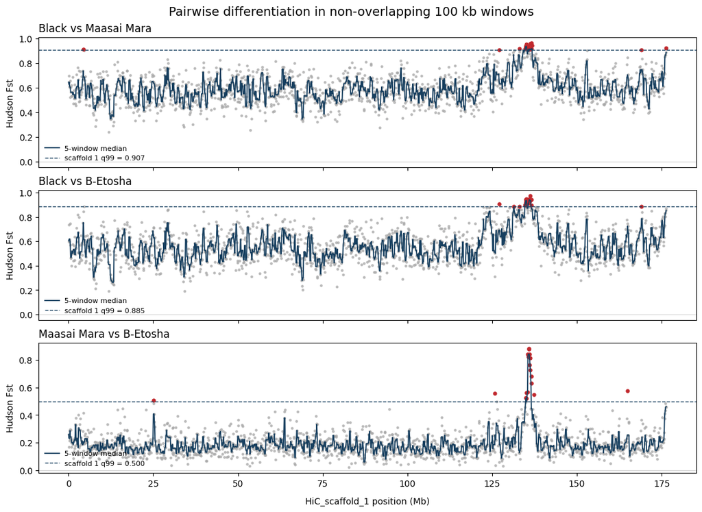

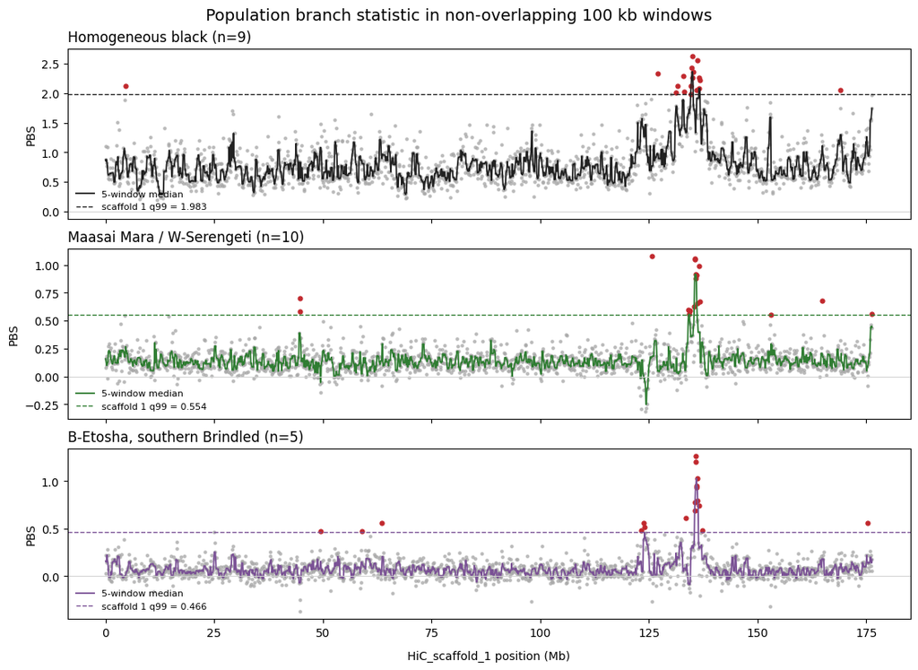

### Quick check: interpreting the wildebeest scan

Run the following cell to check the main methodological points before discussing the biological interpretation.

```
from jupyterquiz import display_quiz

display_quiz('/davidData/users/thomas/workshop/selection_scans_quizzes/wildebeest_interpretation.json')
```

## Questions

1. Which pair of populations has the highest background Fst, and why?
2. Compare the locations and shapes of the three PBS signals around 135–137 Mb. What evidence argues against assigning the entire block to selection on one single branch (one single population)?
3. How does the reported black-to-B-Etosha introgression complicate a simple branch-specific selection interpretation?
4. Which follow-up statistics or quality checks would help distinguish selection from reduced diversity, structural variation, or mapping artefacts?

## Compare with the pre-generated whole-genome scans

The following cell loads two pre-generated figures from the shared workshop directory rather than recomputing them. Their dashed thresholds are genome-wide empirical percentiles, whereas the thresholds in the student-generated plots above are scaffold-1 percentiles.

```
from pathlib import Path
from IPython.display import Image, Markdown, display

data_dir = Path('/davidData/users/thomas/workshop/selection_wildebeest_bonus')

display(Markdown('### Whole-genome pairwise Fst: black versus B-Etosha'))
display(Image(filename=str(data_dir / 'whole_genome.black_vs_b_etosha.fst.png'), width=1100))

display(Markdown('### Whole-genome PBS: black, Maasai Mara, and B-Etosha'))
display(Image(filename=str(data_dir / 'whole_genome.black_maasai_mara_b_etosha.pbs.png'), width=1100))
```

Whole-genome pairwise Fst: black versus B-Etosha

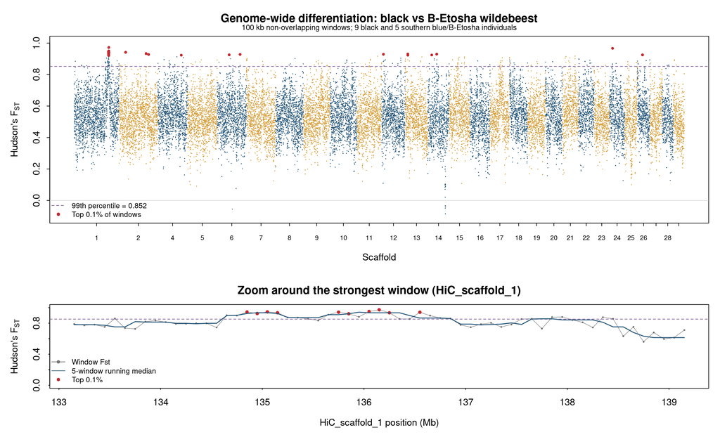

Whole-genome PBS: black, Maasai Mara, and B-Etosha

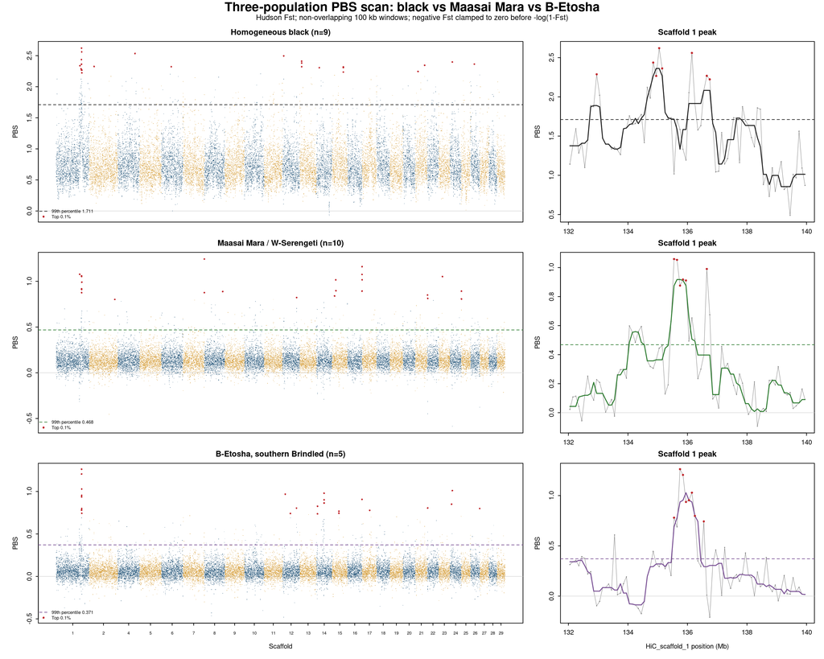

## Interpretation and limitations

The scaffold 1 block is not attributable to a single terminal branch. The black branch reaches its maximum at 135.0–135.1 Mb and B-Etosha at 135.7–135.8 Mb; Maasai Mara is also locally elevated. In the whole-genome scan, the strongest Maasai Mara branch window is instead on scaffold 7 at 114.6–114.7 Mb.

This is a candidate-generating scan, not proof of selection. The article inferred ancient black-to-B-Etosha introgression in the broad scaffold 1 region, violating the simple bifurcating-tree interpretation of PBS. Follow-up should examine diversity, $D_{xy}$, LD, missingness, variant density, mapping quality, and gene annotations.

The current VCF is globally MAF-filtered and lightly LD-pruned, so it is not suitable for unbiased Tajima's D or nucleotide-diversity estimation. Shared wildebeest inputs and pre-generated figures are in `/davidData/users/thomas/workshop/selection_wildebeest_bonus/`; intermediate results are written to `~/wildebeest_bonus_run/`. The notebook implementation agrees with the retained upstream scikit-allel Fst calculation to less than $5\times10^{-16}$.